# Data Cleaning and Exploratory Data Analysis (EDA) for Steam Indie Games Dataset

## **1. Introduction**

The objective of this notebook is to clean, preprocess, and perform an exploratory data analysis (EDA) on the dataset of indie games from the Steam platform. This dataset, collected through the Steam Web API, contains comprehensive metadata about various games, including features like price, genre, developer information, release date, and user engagement metrics.

By utilizing effective data cleaning and EDA techniques, we aim to understand the key characteristics of the dataset, detect patterns and correlations, and prepare a high-quality dataset for the predictive analysis phase of this project. The insights gained in this phase will help determine which features are most relevant for predicting game success and guide us in the development of machine learning models.

## **2. Objectives of the Notebook**

1. **Data Cleaning**:
   - Handle missing values and correct inconsistencies in the dataset.
   - Engineer relevant features to provide additional context and improve the predictive capabilities of the dataset.
   - Normalize features to ensure that the dataset is prepared for advanced analysis and machine learning.
2. **Exploratory Data Analysis (EDA)**:
   - Visualize the distribution of key numerical features to understand underlying patterns.
   - Identify relationships between features, such as price, user recommendations, and genre.
   - Use visual tools such as distribution plots, correlation heatmaps, and boxplots to explore the data and inform feature selection.

## **3. Data Cleaning Overview**

The cleaning process involves addressing missing values, engineering new features, and scaling numerical variables. Key transformations include:

- **Handling Missing Values**: Imputing missing numerical values and removing records that lack critical information.
- **Feature Engineering**: Adding new attributes, such as "Years Since Release," to provide additional temporal context.
- **Normalization**: Scaling key numerical features using Min-Max normalization to maintain consistency and aid in predictive modeling.

This section is critical in ensuring that the data is complete, accurate, and prepared for the next phase of analysis.

## **4. Exploratory Data Analysis Overview**

In this section, we focus on exploring the dataset to gain deeper insights and identify potential relationships among features:

- We employ **distribution plots** to visualize pricing trends, **heatmaps** to understand correlations among features, and **boxplots** to explore the variations in price across different genres.
- These visualizations allow us to formulate hypotheses about what might influence game popularity and success, which will be valuable for model building in subsequent stages.

## **6. Next Steps**

The insights gained from this notebook will serve as the foundation for the next stage of the project: **Predictive Analysis**. Using the cleaned and preprocessed dataset, we will develop machine learning models to predict the commercial success of indie games on Steam. The features identified in the EDA phase will play a key role in building effective models.

By the end of this notebook, we aim to have a clean, well-understood dataset that is ready for machine learning modeling, and a solid grasp of the data's underlying patterns and relationships.

```python
# Cell 1: Import Libraries
import pandas as pd
import numpy as np
import matplotlib.pyplot as plt
import seaborn as sns
from sklearn.preprocessing import StandardScaler, MinMaxScaler, MultiLabelBinarizer
```

```python
# Cell 2: Load Data
# Function to load the data
data_path = r'C:\Users\derek\OneDrive\Documents\Capstone\steam-indie-success\data\steam_indie_games_balanced.csv'

# Load the data into a DataFrame
df = pd.read_csv(data_path, encoding='utf-8')

# Display the first few rows and general data information
print(df.head(10))
print(df.info())
```

```
     AppID                             Game Name  Release Date  \
0  2193070                      Returning To Mia  Oct 27, 2023
1   328940                          The Deer God  Feb 27, 2015
2  2738050                  エスカレーター |  Escalator   Jan 6, 2024
3  1634150  Behind the Frame: The Finest Scenery  Aug 25, 2021
4   391260                         Labyronia RPG  Aug 14, 2015
5   311400                     OCEAN CITY RACING  Nov 14, 2014
6  1329600                               Karting  Apr 15, 2021
7  1245430                          Golden Light  Mar 11, 2022
8   314180                           Deathsmiles  Mar 10, 2016
9  2482440              Leap up no Justu: Double  Dec 21, 2023

                             Developer  \
0                        Inceton games
1  Crescent Moon Games, Cinopt Studios
```

[output cut: 48 more lines]

```python
# Cell 3: Remove Columns Not Suitable for Academic Purposes
if 'Nudity' in df.columns and 'Sexual Content' in df.columns:
    df = df.drop(columns=['Nudity', 'Sexual Content'])
```

```
Missing values:
 AppID                 0
Game Name             0
Release Date          0
Developer             0
Genres                0
Price ($)             0
Recommendations       0
Metacritic Score    254
dtype: int64
```

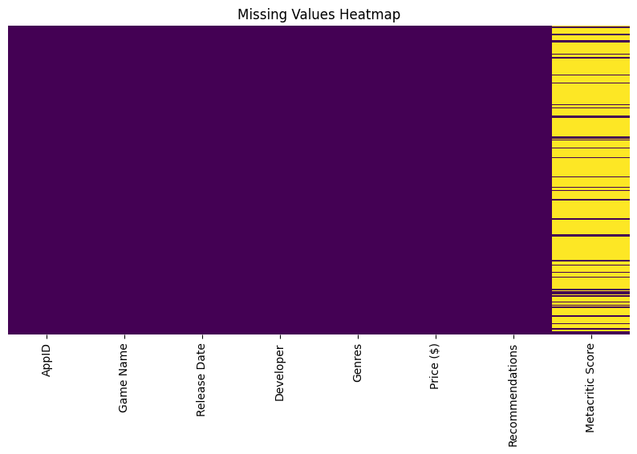

```python
# Cell 4: Check for Missing Values

missing_values = df.isna().sum()
print("Missing values:\n", missing_values)

# Visualize missing values
plt.figure(figsize=(10, 5))
sns.heatmap(df.isna(), cbar=False, cmap='viridis', yticklabels=False)
plt.title('Missing Values Heatmap')
plt.show()
```

```python
# Cell 5: Data Cleaning - Dates, Prices, and Text Data

# Step 1: Convert 'Release Date' to datetime
df['Release Date'] = pd.to_datetime(df['Release Date'], errors='coerce')
print(f"Number of invalid dates: {df['Release Date'].isna().sum()}")

# Step 2: Convert 'Price ($)' to numeric
df['Price ($)'] = pd.to_numeric(df['Price ($)'].str.replace('$', '', regex=True), errors='coerce')
print(f"Number of invalid price entries: {df['Price ($)'].isna().sum()}")

# Step 3: Handle missing values in 'Metacritic Score' by filling with median
df['Metacritic Score'].fillna(df['Metacritic Score'].median(), inplace=True)

# Step 4: Clean text data
for col in ['Game Name', 'Developer', 'Genres']:
    df[col] = df[col].str.strip()

# Display updated missing values
print(df.isna().sum())
```

```
Number of invalid dates: 6
Number of invalid price entries: 6
AppID               0
Game Name           0
Release Date        6
Developer           0
Genres              0
Price ($)           6
Recommendations     0
Metacritic Score    0
dtype: int64
```

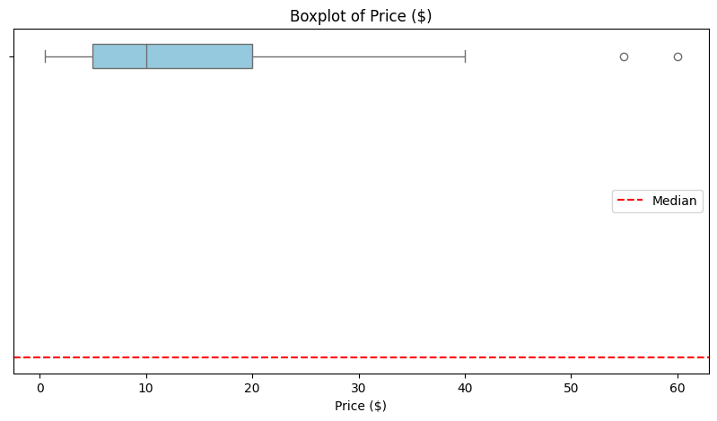

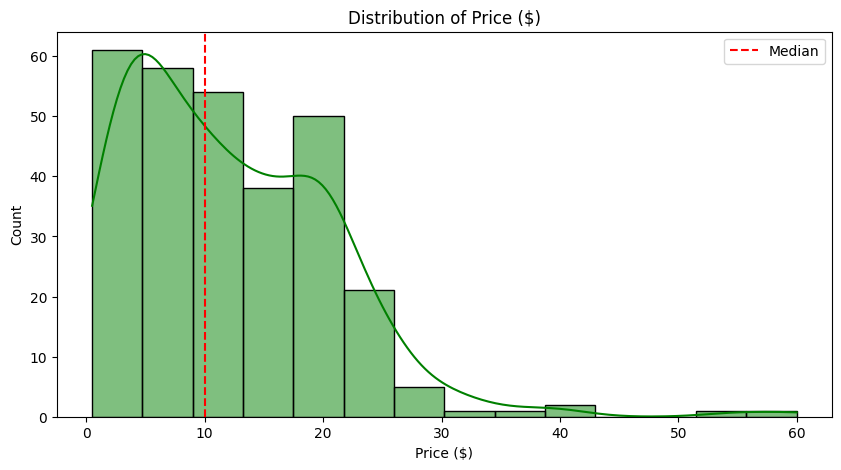

```python
# Cell 6: Boxplot and Histogram for Price

# Boxplot for Price ($)
plt.figure(figsize=(10, 5))
sns.boxplot(data=df, x='Price ($)', color='skyblue')
plt.axhline(df['Price ($)'].median(), color='red', linestyle='--', label='Median')
plt.title('Boxplot of Price ($)')
plt.xlabel('Price ($)')
plt.legend()
plt.show()

# Histogram of Price
plt.figure(figsize=(10, 5))
sns.histplot(df['Price ($)'], kde=True, color='green')
plt.axvline(df['Price ($)'].median(), color='red', linestyle='--', label='Median')
plt.title('Distribution of Price ($)')
plt.xlabel('Price ($)')
plt.legend()
plt.show()
```

```
Number of outliers in 'Price ($)': 2
           Game Name  Price ($)
29      Dude Fighter      59.99
175  Legendary Tales      54.99
```

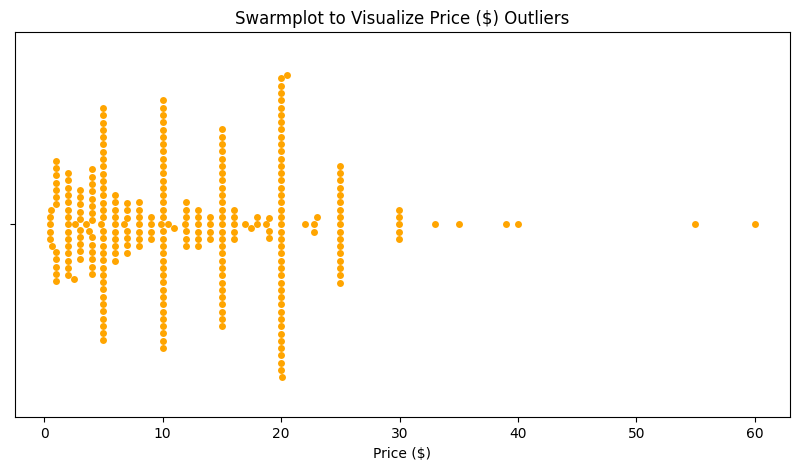

```python
# Cell 7: Identify Outliers for Price

# Calculate IQR for identifying outliers
Q1 = df['Price ($)'].quantile(0.25)
Q3 = df['Price ($)'].quantile(0.75)
IQR = Q3 - Q1

lower_bound = Q1 - 1.5 * IQR
upper_bound = Q3 + 1.5 * IQR

# Finding the outliers
outliers = df[(df['Price ($)'] < lower_bound) | (df['Price ($)'] > upper_bound)]
print("Number of outliers in 'Price ($)':", outliers.shape[0])
print(outliers[['Game Name', 'Price ($)']])

# Swarmplot to visualize outliers
plt.figure(figsize=(10, 5))
sns.swarmplot(data=df, x='Price ($)', color='orange')
plt.title('Swarmplot to Visualize Price ($) Outliers')
plt.xlabel('Price ($)')
plt.show()
```

```python
# Cell 8: Remove Duplicate Rows

print(f"Number of duplicate rows: {df.duplicated().sum()}")
df.drop_duplicates(inplace=True)
print(f"Number of rows after removing duplicates: {df.shape[0]}")
```

```
Number of duplicate rows: 0
Number of rows after removing duplicates: 299
```

```python
# Cell 9: Process Genres Column

# Convert the Genres column into a list of genres for each game
df['Genres'] = df['Genres'].apply(lambda x: [genre.strip() for genre in x.split(',')])

# Use MultiLabelBinarizer to create separate columns for each genre
mlb = MultiLabelBinarizer()
genres_encoded = mlb.fit_transform(df['Genres'])

# Create a new DataFrame with the genre columns and add it to the original DataFrame
genres_df = pd.DataFrame(genres_encoded, columns=mlb.classes_, index=df.index)
df = pd.concat([df, genres_df], axis=1)

# Drop the original 'Genres' column
df.drop('Genres', axis=1, inplace=True)
print(df.head())
```

```
     AppID                             Game Name Release Date  \
0  2193070                      Returning To Mia   2023-10-27
1   328940                          The Deer God   2015-02-27
2  2738050                  エスカレーター |  Escalator   2024-01-06
3  1634150  Behind the Frame: The Finest Scenery   2021-08-25
4   391260                         Labyronia RPG   2015-08-14

                             Developer  Price ($)  Recommendations  \
0                        Inceton games      14.99              193
1  Crescent Moon Games, Cinopt Studios      14.99              220
2                              Toyasky       2.99              116
3                 Silver Lining Studio      12.99             4321
4                         Labyrinthine       1.99             1116

   Metacritic Score  Action  Adventure  Casual  ...  Indie  \
```

[output cut: 21 more lines]

```python
# Cell 10: Scaling Numerical Features

# Select numerical columns to normalize, excluding Recommendations
num_cols = ['Price ($)', 'Metacritic Score']

# Apply MinMaxScaler to normalize only Price and Metacritic Score
scaler = MinMaxScaler()
df[num_cols] = scaler.fit_transform(df[num_cols])

print(df[['Price ($)', 'Metacritic Score', 'Recommendations']].head())
```

```
   Price ($)  Metacritic Score  Recommendations
0   0.243697              0.70              193
1   0.243697              0.25              220
2   0.042017              0.70              116
3   0.210084              0.70             4321
4   0.025210              0.70             1116
```

```python
# Cell 11: One-Hot Encoding for Developer Column

developer_counts = df['Developer'].value_counts()
top_developers = developer_counts[developer_counts > 1].index  # Keep developers with more than 1 game
df['Developer'] = df['Developer'].apply(lambda x: x if x in top_developers else 'Other')

developer_dummies = pd.get_dummies(df['Developer'], prefix='Developer')
df = pd.concat([df, developer_dummies], axis=1)

# Drop the original 'Developer' column
df.drop('Developer', axis=1, inplace=True)
print(df.head())
```

```
     AppID                             Game Name Release Date  Price ($)  \
0  2193070                      Returning To Mia   2023-10-27   0.243697
1   328940                          The Deer God   2015-02-27   0.243697
2  2738050                  エスカレーター |  Escalator   2024-01-06   0.042017
3  1634150  Behind the Frame: The Finest Scenery   2021-08-25   0.210084
4   391260                         Labyronia RPG   2015-08-14   0.025210

   Recommendations  Metacritic Score  Action  Adventure  Casual  Early Access  \
0              193              0.70       0          1       1             0
1              220              0.25       0          0       0             0
2              116              0.70       0          1       0             0
3             4321              0.70       0          1       1             0
4             1116              0.70       1          1       0             0

   ...  Strategy  Violent  Developer_Alister Software  \
```

[output cut: 28 more lines]

```python
# Cell 12: Drop Rows with Missing Critical Values and Add Years Since Release

df.dropna(subset=['Release Date', 'Price ($)'], inplace=True)
print(f"Number of rows after dropping missing values: {df.shape[0]}")

# Convert 'Release Date' to datetime format and add 'Years Since Release'
df['Release Date'] = pd.to_datetime(df['Release Date'], errors='coerce')
df['Years Since Release'] = 2024 - df['Release Date'].dt.year
print(df[['Release Date', 'Years Since Release']].head())
```

```
Number of rows after dropping missing values: 287
  Release Date  Years Since Release
0   2023-10-27                    1
1   2015-02-27                    9
2   2024-01-06                    0
3   2021-08-25                    3
4   2015-08-14                    9
```

```python
# Cell 13: Convert Columns to Appropriate Data Types

# Convert 'Recommendations' to integer if they are whole numbers
df['Recommendations'] = df['Recommendations'].astype('int64')

genre_columns = mlb.classes_
for col in genre_columns:
    df[col] = df[col].astype('bool')

print("Final data types:")
print(df.dtypes)
```

```
Final data types:
AppID                                        int64
Game Name                                   object
Release Date                        datetime64[ns]
Price ($)                                  float64
Recommendations                              int64
Metacritic Score                           float64
Action                                        bool
Adventure                                     bool
Casual                                        bool
Early Access                                  bool
Free To Play                                  bool
Gore                                          bool
Indie                                         bool
Massively Multiplayer                         bool
Nudity                                        bool
RPG                                           bool
Racing                                        bool
Sexual Content                                bool
Simulation                                    bool
Sports                                        bool
Strategy                                      bool
Violent                                       bool
Developer_Alister Software                    bool
Developer_Choice of Games                     bool
Developer_Daedalic Entertainment              bool
Developer_Easy game                           bool
Developer_Other                               bool
Developer_RewindApp                           bool
Developer_Ronimo Games                        bool
Developer_U-ROOM                              bool
Years Since Release                          int32
dtype: object
```

```python
# Cell 14: Save cleaned dataset to a CSV file

cleaned_data_path = r'C:\Users\derek\OneDrive\Documents\Capstone\steam-indie-success\data\steam_indie_games_cleaned.csv'
df.to_csv(cleaned_data_path, index=False)
print("Cleaned dataset saved as 'steam_indie_games_cleaned.csv'")
```

```
Cleaned dataset saved as 'steam_indie_games_cleaned.csv'
```

```
              AppID                   Release Date   Price ($)  \
count  2.870000e+02                            287  287.000000
mean   1.196220e+06  2020-01-10 12:17:33.658536704    0.189637
min    4.000000e+03            2006-11-29 00:00:00    0.000000
25%    4.459700e+05            2018-03-10 12:00:00    0.075630
50%    1.110050e+06            2020-09-23 00:00:00    0.159664
75%    1.677880e+06            2023-03-22 00:00:00    0.308824
max    3.172860e+06            2024-10-01 00:00:00    1.000000
std    7.713012e+05                            NaN    0.146408

       Recommendations  Metacritic Score  Years Since Release
count       287.000000        287.000000           287.000000
mean       5896.811847          0.688589             4.487805
min         101.000000          0.000000             0.000000
25%         176.000000          0.700000             1.000000
50%         399.000000          0.700000             4.000000
75%        1205.000000          0.700000             6.000000
max      951940.000000          0.975000            18.000000
std       57090.504897          0.096748             3.677425
```

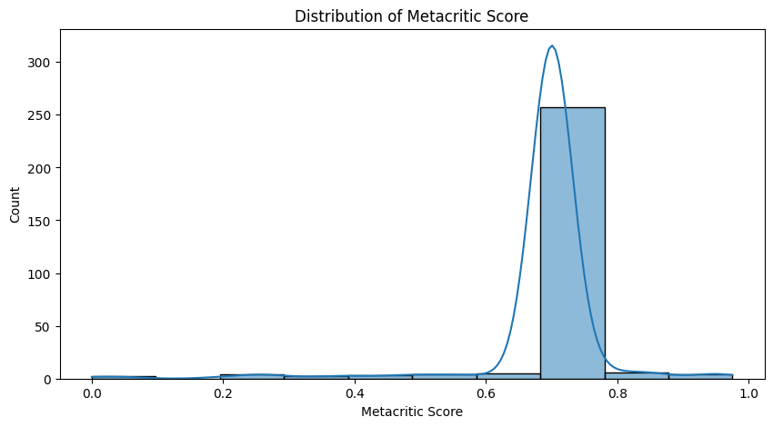

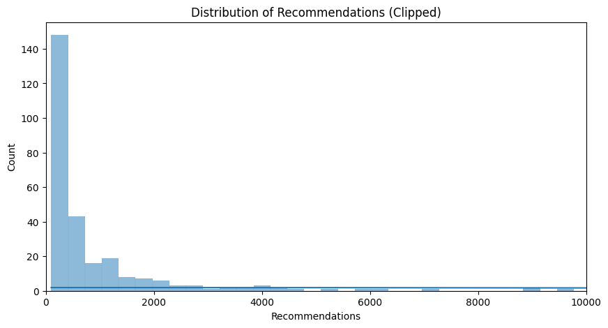

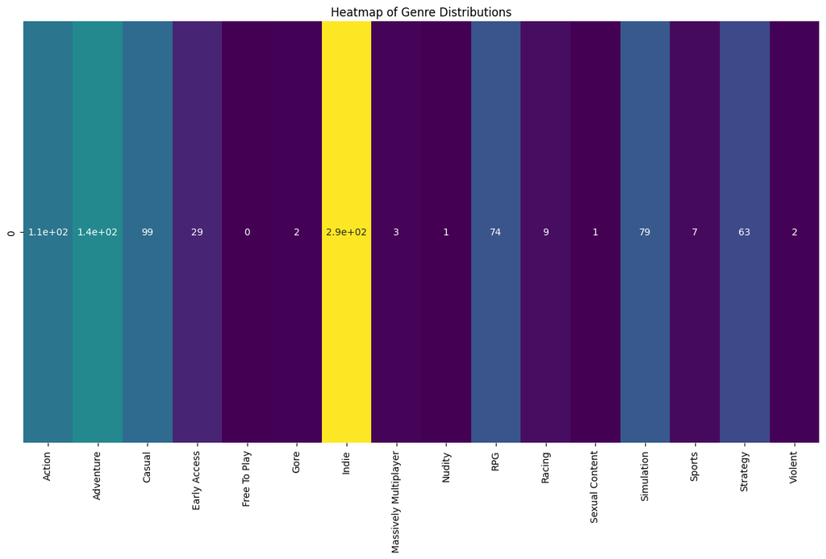

```python
# Cell 15: Summary Statistics and Data Visualization

# Display summary statistics for all numerical columns
print(df.describe())

# Histogram for Metacritic Score
plt.figure(figsize=(10, 5))
sns.histplot(df['Metacritic Score'], kde=True)
plt.title('Distribution of Metacritic Score')
plt.xlabel('Metacritic Score')
plt.show()

# Histogram for Recommendations with a clipped x-axis for readability
plt.figure(figsize=(10, 5))
sns.histplot(df['Recommendations'], kde=True)
plt.title('Distribution of Recommendations (Clipped)')
plt.xlabel('Recommendations')
plt.ylabel('Count')
plt.xlim(0, 10000)
plt.show()

# Heatmap of genre distributions
plt.figure(figsize=(15, 8))
sns.heatmap(df[genre_columns].sum().to_frame().T, annot=True, cmap='viridis', cbar=False)
plt.title('Heatmap of Genre Distributions')
plt.show()
```

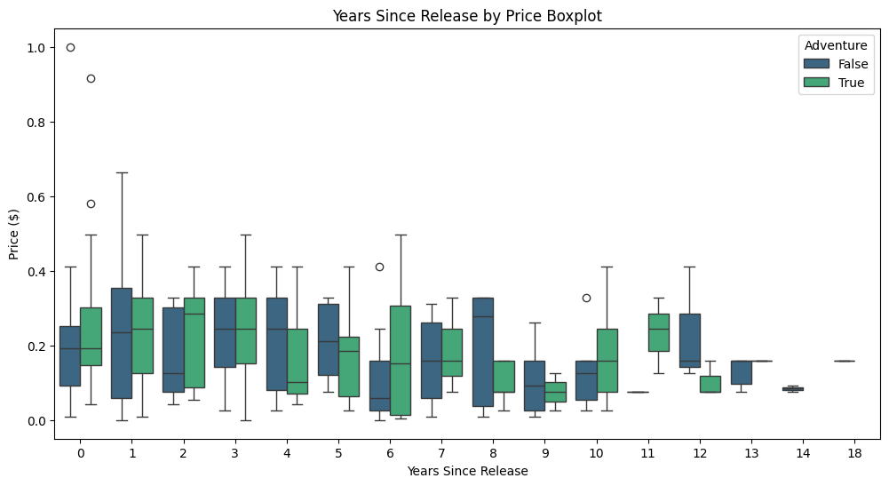

```python
# Cell 16: Boxplot for Years Since Release vs. Price

plt.figure(figsize=(12, 6))
sns.boxplot(data=df, x='Years Since Release', y='Price ($)', hue='Adventure', palette='viridis')
plt.title('Years Since Release by Price Boxplot')
plt.show()
```

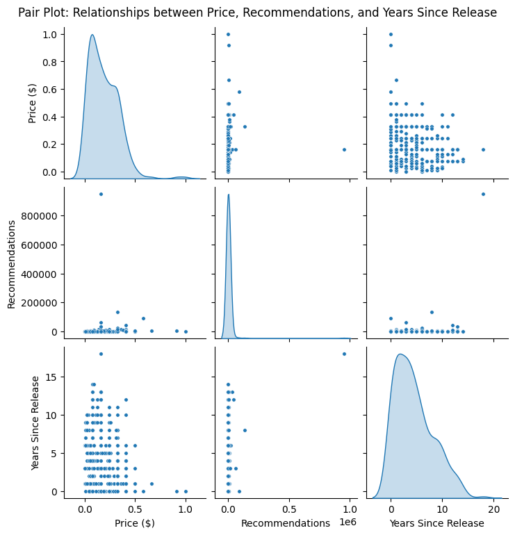

```python
# Cell 17: Pair Plot for Numerical Features

numeric_cols_subset = df[['Price ($)', 'Recommendations', 'Years Since Release']]
sns.pairplot(numeric_cols_subset, diag_kind='kde', plot_kws={"s": 15})
plt.suptitle('Pair Plot: Relationships between Price, Recommendations, and Years Since Release', y=1.02)
plt.show()
```

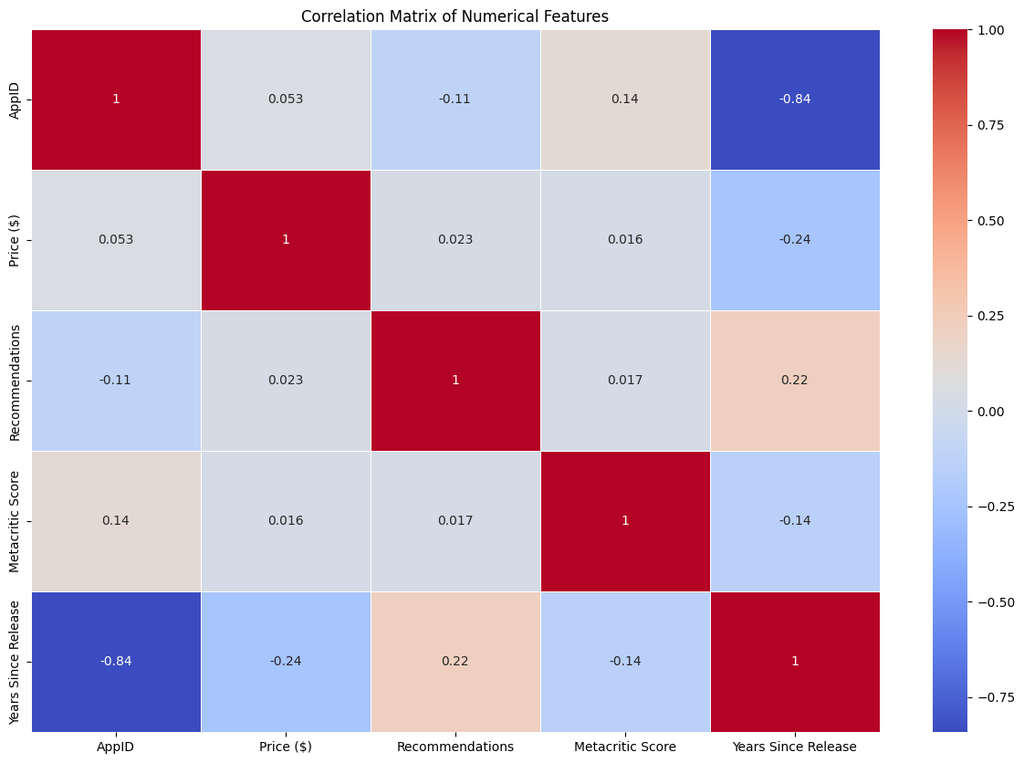

```python
# Cell 18: Correlation Matrix

plt.figure(figsize=(15, 10))
corr_matrix = df.select_dtypes(include=['number']).corr()
sns.heatmap(corr_matrix, annot=True, cmap='coolwarm', linewidths=0.5)
plt.title('Correlation Matrix of Numerical Features')
plt.show()
```

```python
# Cell 19: Final Check for Missing Values and Data Types


print("Final check for missing values:")
print(df.isna().sum())

print("\nFinal data types:")
print(df.dtypes)
```

```
Final check for missing values:
AppID                               0
Game Name                           0
Release Date                        0
Price ($)                           0
Recommendations                     0
Metacritic Score                    0
Action                              0
Adventure                           0
Casual                              0
Early Access                        0
Free To Play                        0
Gore                                0
Indie                               0
Massively Multiplayer               0
Nudity                              0
RPG                                 0
Racing                              0
Sexual Content                      0
Simulation                          0
Sports                              0
Strategy                            0
Violent                             0
Developer_Alister Software          0
Developer_Choice of Games           0
Developer_Daedalic Entertainment    0
Developer_Easy game                 0
Developer_Other                     0
Developer_RewindApp                 0
Developer_Ronimo Games              0
Developer_U-ROOM                    0
Years Since Release                 0
dtype: int64

Final data types:
AppID                                        int64
Game Name                                   object
Release Date                        datetime64[ns]
Price ($)                                  float64
Recommendations                              int64
```

[output cut: 12 more lines]

```
Sexual Content                                bool
Simulation                                    bool
Sports                                        bool
Strategy                                      bool
Violent                                       bool
Developer_Alister Software                    bool
Developer_Choice of Games                     bool
Developer_Daedalic Entertainment              bool
Developer_Easy game                           bool
Developer_Other                               bool
Developer_RewindApp                           bool
Developer_Ronimo Games                        bool
Developer_U-ROOM                              bool
Years Since Release                          int32
dtype: object
```

```python
# Cell 20: Remove the Metacritic Score column due to high missing values
# Reason: The column has ~85% missing data, and its utility is minimal for modeling.

df = df.drop(columns=['Metacritic Score'])

print("Metacritic Score column removed.")

# (Optional) Save the updated cleaned dataset
cleaned_data_path = r'C:\Users\derek\OneDrive\Documents\Capstone\steam-indie-success\data\steam_indie_games_cleaned_v2.csv'
df.to_csv(cleaned_data_path, index=False)
print(f"Updated cleaned dataset saved to: {cleaned_data_path}")
```

```
Metacritic Score column removed.
Updated cleaned dataset saved to: C:\Users\derek\OneDrive\Documents\Capstone\steam-indie-success\data\steam_indie_games_cleaned_v2.csv
```

## Cell 21: Additional Refinements

In this step, we make additional improvements to the dataset:

```python
# Convert 'Release Date' to datetime format if not already done
df['Release Date'] = pd.to_datetime(df['Release Date'], errors='coerce')

# Preserve a copy of the original Recommendations column before transformations
df['Original_Recommendations'] = df['Recommendations']

# Log-transform Recommendations to handle skewness
df['Log_Recommendations'] = np.log1p(df['Recommendations'])

# Standardize numerical columns for modeling readiness
df[['Standardized_Recommendations', 'Years Since Release']] = scaler.fit_transform(
    df[['Recommendations', 'Years Since Release']]
)

# Drop the redundant Recommendations column
df.drop(columns=['Recommendations'], inplace=True)

# Verify the datetime conversion
print(df['Release Date'].head())

# Save the updated dataset with a versioned name
final_path = r"C:\Users\derek\OneDrive\Documents\Capstone\steam-indie-success\data\steam_indie_games_cleaned_v3.csv"
df.to_csv(final_path, index=False)
print("Dataset saved to:", final_path)
```

```
0   2023-10-27
1   2015-02-27
2   2024-01-06
3   2021-08-25
4   2015-08-14
Name: Release Date, dtype: datetime64[ns]
Dataset saved to: C:\Users\derek\OneDrive\Documents\Capstone\steam-indie-success\data\steam_indie_games_cleaned_v3.csv
```